# 第13回 そのグループ分けは、妥当か

エルボー・シルエット・種の揺れ・大陸とのARI

# 導入

## 前回：銀河は、約145のグループに

- 著者のコードで、銀河が約145のグループに分かれた
- グループの数は、方法まかせだった

## 第11回：3つのグループに分けた

- 142か国を、最貧・新興・先進に分けた
- でも、K＝3はこちらで決めた数

## 2つや5つでは、だめなのか

- 正解のラベルがないので、「当たったか」では測れない
- ラベルのないグループ分けの、良し悪しを測る物差しが要る

## 報告書に載せる前に

- あなたは、国際協力機関の担当者
- 上司に、「なぜ3つなのか」を数の根拠で説明したい

## 今日の問い

3つのグループ分けは、妥当か？Kをいくつにすべきか、根拠をもって言えるか？

## 今日のコードの書き方

- Kごと・乱数の種ごとの結果を、リストや辞書に集める
- 集めた結果を、表にして比べる
- 条件に合う数を、`sum`で数える

## この問いに、どう近づくか

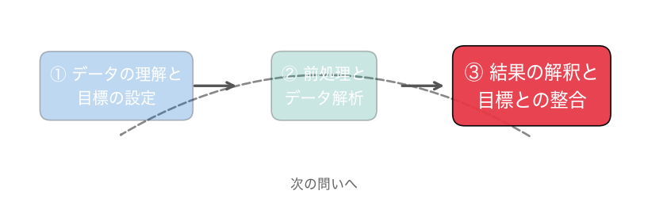

③の目標との整合（その分け方で、報告に耐えるか）。

# 0. 設定

## やってみよう：0節

- 第13回のノートを開き、ドライブにコピーする
- 0節のセルを実行する。前回と同じ142か国の表ができる

動画の人は、ここで一時停止。

# 1. 慣性は、必ず下がる

## まず、前回の物差しで比べる

- 前回は、分け方の良し悪しを慣性で測った
- Kを2〜8に変えて、慣性を並べてみる

## おさらい：forとリスト

```python
out = []
for i in range(3):
    out.append(i * 10)   # out は [0, 10, 20]
```

- 空のリストに、`append`で1つずつ足していく（第4回）

## お手本：Kごとの慣性

```python
ks = range(2, 9)
inertias = []
for k in ks:
    km = KMeans(n_clusters=k, n_init=10, random_state=42).fit(X)
    inertias.append(km.inertia_)
print(np.round(inertias, 1))
```

- 役割：Kを2〜8に変えて、慣性をリストに集める

## やってみよう：1節

- 1節のお手本のセルを実行する
- Kを増やすと、慣性はどう動くか？

動画の人は、ここで一時停止。

## 答え合わせ：下がり続ける

```
[84.2 53.8 37.1 25.1 19.2 16.  13.8]
```

- 一度も上がらずに、下がり続ける

## なぜ、必ず下がるのか

- Kを1つ増やせば、広がったグループを2つに割るだけでも、距離の合計は小さくなる
- Kを142にすれば、どの国も自分が中心。慣性は0

## いちばん小さいKは、選べない

- 慣性だけなら、「Kは多いほどよい」になってしまう
- かわりに、下がり方の曲がり角を探す

## エルボー

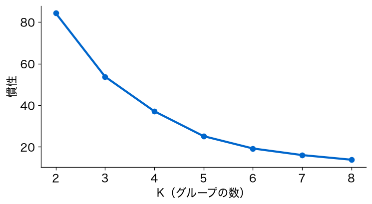

- 下がり幅は2→3で30、17、12、6、3と小さくなる
- どこで曲がっているか？

## 曲がり角は、3か5か

- 3のあとで小さくなりはじめ、5のあとでもう一度半分（12→6）

## エルボーは、読み方が分かれる

- はっきりした角はない。K＝3ともK＝5とも読める

# 2. シルエット

## エルボーでは決まらない。では？

- 曲がり角は、3とも5とも読めた
- 国ごとの収まり具合で測る、別の物差しを使う

## しっくり収まっているか

- 1か国ずつ、「今のグループに収まっているか」を −1〜1の数に
- 全国の平均が、シルエット（大きいほどよい）

## シルエット係数の式

$$s_i = \frac{b_i - a_i}{\max(a_i,\ b_i)}$$

- $a_i$：同じグループの国までの、距離の平均
- $b_i$：いちばん近い別のグループの国までの、距離の平均

## 読み方

- 1に近い：しっくり収まっている
- 0に近い：境目
- マイナス：別のグループのほうが近い

## お手本：K＝3のシルエット

```python
km3 = KMeans(n_clusters=3, n_init=10, random_state=42).fit(X)
print(round(silhouette_score(X, km3.labels_), 3))
s = silhouette_samples(X, km3.labels_)         # 国ごとのシルエット
print(d.loc[s < 0, 'country'].tolist())
```

## おさらい：辞書にためる

```python
d = {}
for i in range(3):
    d[i] = i * 10        # d は {0: 0, 1: 10, 2: 20}
```

- 辞書は、名前（キー）と値の組を覚えておく入れ物（第3回）
- `for`で取り出し、`d[キー] = 値`でキーと値をためる

## TODO①：Kごとに、辞書へ

```python
# TODO: K＝2〜8 のシルエットを辞書 sil に集めて表示する
# ヒント: sil = {} → for k in ks: の中で
#         sil[k] = silhouette_score(X, KMeans(…).fit_predict(X))
...
```

- どのKで最大になるか？

## やってみよう：2節とTODO①

- 2節のお手本のセルを実行する
- TODO①：Kごとのシルエットを、辞書に集める

動画の人は、ここで一時停止。

## 答え合わせ：0.513

```
0.513
['Iraq', 'Sao Tome and Principe', 'Trinidad and Tobago']
```

- マイナスは3か国

## 国ごとのシルエット

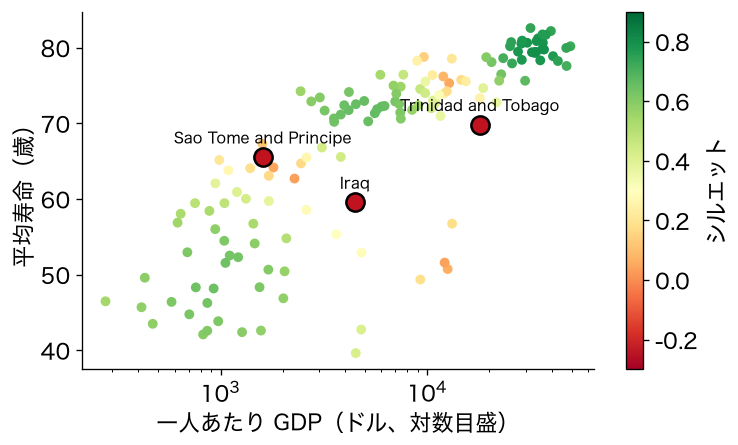

- 緑ほどしっくり。黄〜橙がグループのあいだの境目
- 大きな赤丸の3か国が、マイナス

## 別の物差しでも、同じ国

- トリニダードトバゴとイラクは、前回のTODO④で見つけた境目の国
- 物差しを変えても、同じ国が境目に出てくる

## 答え合わせ：TODO①

```
{2: 0.599, 3: 0.513, 4: 0.479, 5: 0.514, 6: 0.49, 7: 0.474, 8: 0.461}
```

## シルエットは、K＝2を推す

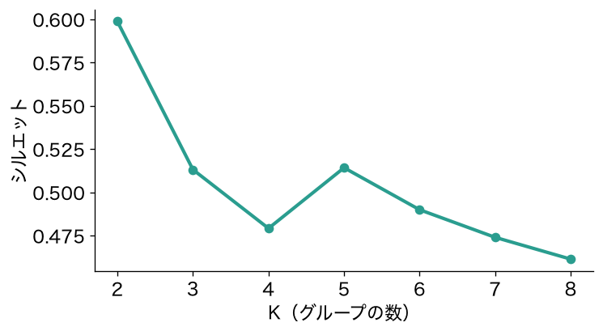

- K＝2が0.599で最大

## 次は、K＝5とK＝3

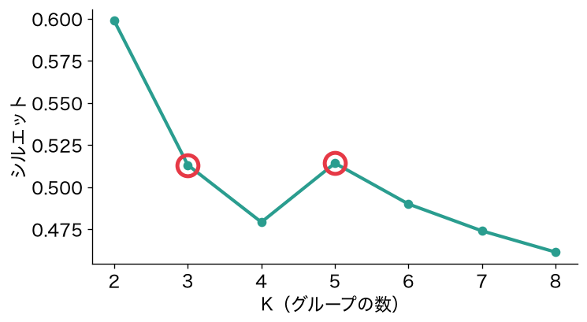

- 2番目はK＝5（0.514）、3番目がK＝3（0.513）。ほぼ同点

## 2つで、よいのか

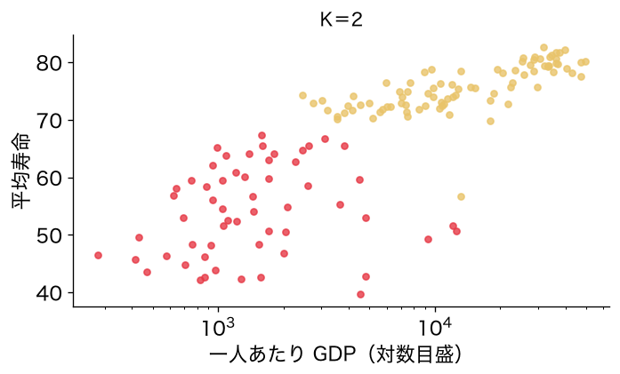

- 「豊かで長寿」と「そうでない」の2つに分かれる

## 2つは、大ざっぱすぎる

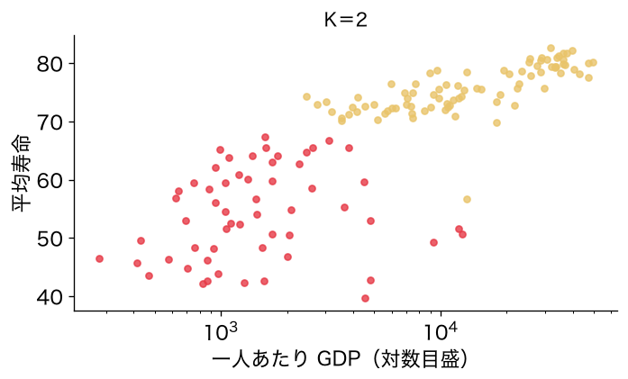

- 支援の方針を立てるには、2つでは大ざっぱすぎる

## K＝5は、どんな分け方か

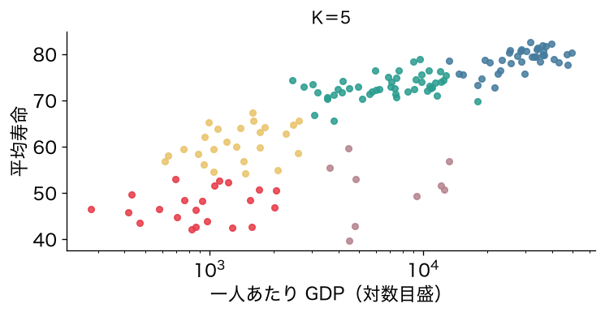

- エルボーでもシルエットでも、K＝3と並ぶ候補。5つは、どんな国々か？

## 寿命の4段と、GDPの割に短命な国

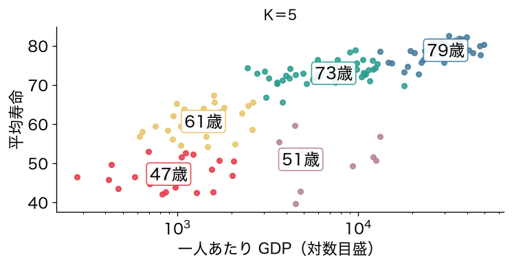

- 平均寿命47・61・73・79歳の4段
- もう1つは、GDPの割に短命な9か国（51歳）

## 5つは、細かい違いを見せる

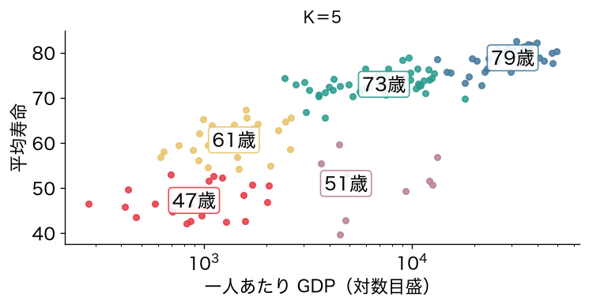

- 「最貧」が割れ、GDPの割に短命な国が抜け出す
- 3と5のどちらを載せるかは、物差しだけでは決まらない

## 物差しの最良と、目的の最良

- 物差しがいちばんよいKが、目的にいちばんよいKとは限らない
- 目的から決めるのは、5節

# 3. 種で、揺れるか

## 候補は絞れた。分け方は揺れないか

- エルボーとシルエットで、候補は2・3・5に残った
- 報告に載せるなら、分け方が安定していることも確かめたい

## 出発点は、乱数で決まる

- k-meansの答えは、出発点で変わる（前回）
- 乱数の種を変えると、分け方も変わるかもしれない

## お手本：出発点1つで、種を5通り

```python
for seed in range(5):
    k1 = KMeans(n_clusters=3, n_init=1, random_state=seed).fit(X)
    ari = adjusted_rand_score(km3.labels_, k1.labels_)
    print(seed, round(k1.inertia_, 2), round(ari, 3))
```

- `n_init=1`：出発点を1つだけ
- ARI：2つの分け方の一致度。同じ分け方なら1（第11回）

## 新しい書き方：sumで数える

```python
print(sum(v >= 0.95 for v in [0.4, 0.98, 0.99]))   # 2 と表示される
```

- 「0.95以上は、いくつか」を1行で数える書き方

## Trueを1、Falseを0として足す

```python
print(sum(v >= 0.95 for v in [0.4, 0.98, 0.99]))   # 2 と表示される
```

- `for v in …`：並びの中身を1つずつ`v`に入れる
- `v >= 0.95`：`v`ごとに`True`か`False`（False・True・True）
- `sum`：Trueを1として足す → 条件に合う数（2）

## TODO②：10通りの種で、数える

```python
# TODO: 種0〜9の ARI を辞書 ari_seed に集め、0.95 以上の数を数える
# ヒント: ari_seed[seed] = adjusted_rand_score(km3.labels_, …)
#         sum(v >= 0.95 for v in ari_seed.values())
...
```

## やってみよう：3節とTODO②

- 3節のお手本のセルを実行する
- TODO②：10通りのうち、`km3`とほぼ同じになるのはいくつ？

動画の人は、ここで一時停止。

## 答え合わせ：大きく揺れる

```
0 57.1 0.397
1 54.67 0.732
2 57.1 0.397
3 55.4 0.571
4 55.4 0.571
```

- ARIは0.40〜0.73。どの種でも、慣性は`km3`（53.75）より大きい

## 種が違えば、グループが違う

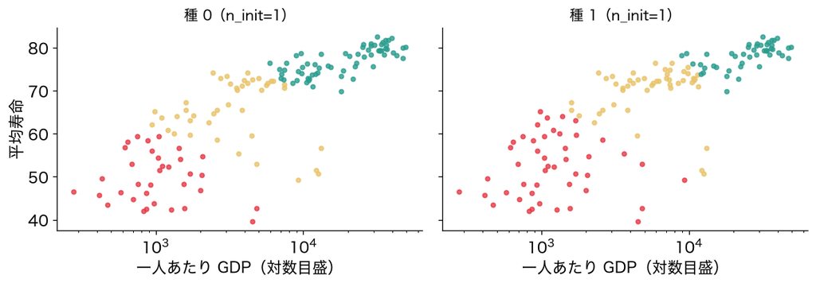

- 色は、平均寿命の低い順に赤・黄・緑でそろえた

## 答え合わせ：TODO②

```
{0: 0.4, 1: 0.73, 2: 0.4, 3: 0.57, 4: 0.57, 5: 0.98, 6: 0.56, 7: 0.57, 8: 0.98, 9: 0.98}
3
```

- 0.95以上は、10通りのうち3通りだけ

## だから、何通りも試す

- 出発点1つでは、同じ分け方にたどり着くとは限らない
- 前回から`n_init=10`を使ってきた理由
- `n_init=10`なら揺れないかは、課題で確かめる

# 4. 大陸と比べる

## 内の物差しと、外の区分

- 慣性とシルエットは、データの形だけから測る
- もう一つ、外の区分と比べる見方がある

## 大陸は、正解ではない

- 重なりが大きい：地理で説明のつく分け方
- 重なりが小さい：地理とは別の切り口
- どちらがよいかは、目的しだい

## お手本：K＝3と大陸

```python
print(round(adjusted_rand_score(d['continent'], km3.labels_), 3))
```

## TODO③：Kごとに、大陸と

```python
# TODO: K＝2〜6 の、大陸との ARI を辞書 ari_cont に集めて表示する
# ヒント: ari_cont[k] = adjusted_rand_score(d['continent'], labels)
...
```

## やってみよう：4節とTODO③

- 4節のお手本のセルを実行する
- TODO③：どのKで、大陸といちばん重なるか？

動画の人は、ここで一時停止。

## 答え合わせ：0.365

```
0.365
```

- 大陸とある程度は重なるが、同じではない

## 答え合わせ：TODO③

```
{2: 0.241, 3: 0.365, 4: 0.226, 5: 0.205, 6: 0.202}
```

- K＝3で最大。地理の言葉で、いちばん説明しやすい

## 報告なら、地理の言葉は強み

- 報告の読み手は、国を地域の名前で思い浮かべる
- 「アフリカ中心の最貧」「ヨーロッパ中心の先進」は、伝わりやすい
- 報告に載せるという今日の目的には、重なりの大きさが利点になる

# 5. 報告に載せるK

## 物差しがそろった。Kはいくつに？

- 慣性・シルエット・大陸とのARIを、Kごとに出した
- 1つの表にまとめて、報告に載せるKを決める

## TODO④：1つの表にする

```python
# TODO: K＝2〜6 の慣性・シルエット・大陸 ARI を1つの表にする
# ヒント: rows = [] → for k in range(2, 7): の中で km を作り、
#         rows.append({'K': k, '慣性': km.inertia_, …})
#         → pd.DataFrame(rows)
...
```

- 第4回・第7回と、同じ作り方

## やってみよう：5節とTODO④

- TODO④：物差しを、1つの表にまとめる
- 報告に載せるKは、いくつにするか？

動画の人は、ここで一時停止。

## 答え合わせ：TODO④

```
 K     慣性  シルエット  大陸ARI
 2 84.221  0.599  0.241
 3 53.753  0.513  0.365
 4 37.110  0.479  0.226
 5 25.146  0.514  0.205
 6 19.230  0.490  0.202
```

## 物差しごとに、推すKが違う

- 慣性（エルボー）：3か5
- シルエット：2（5と3がほぼ同点で次）
- 大陸とのARI：3

## 物差しは、判断の材料

- 1つの正解を出す機械ではない
- 形の物差しだけなら、2・3・5が候補に残る

## 決め手は、目的

- 2つ：支援の方針には大ざっぱすぎる
- 5つ：細かい違いは見えるが、報告の読み手には伝えにくい
- 3つ：「最貧・新興・先進」と、地理の言葉でも伝わる

## 担当者の答え

K＝3を報告に載せる。シルエットはK＝5とほぼ同じ（0.513と0.514）で、大陸との重なりがいちばん大きい（0.365）。地理の言葉で説明でき、報告で伝わりやすい。

## 細かい違いは、補足に

- シルエットがマイナスの3か国（イラクなど）は、「境目の国」として
- K＝5で分かれる、GDPの割に短命な9か国も、補足として示す

## まだ言えないこと①：確率で

- どの国も、1つのグループに必ず入れている
- 「60%は新興、40%は最貧」のように、確率で分けられないか（発展）

## まだ言えないこと②：区分の表

- ジャンルや年代のような、区分どうしの近さは、どう地図にするか

# まとめ

## 今日の歩み

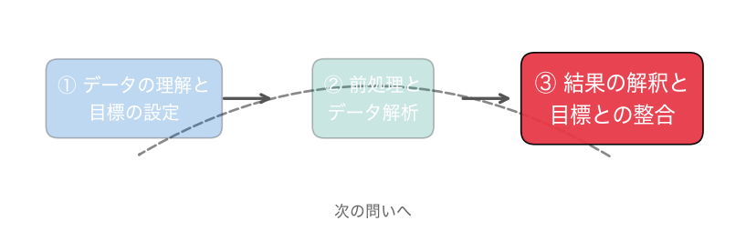

エルボー → シルエット → 種の揺れ → 大陸とのARI → 報告に載せるK

## 今日の要点

- 慣性は必ず下がる。いちばん小さいKではなく、曲がり角を読む
- シルエットは、自分のグループへの近さと、別のグループからの遠さの比べ
- 出発点1つでは揺れる。何通りも試して、安定を確かめる
- 物差しは判断の材料。候補（2・3・5）を絞り、目的に照らしてKを決める
- Python：Kごと・種ごとの結果を、リストや辞書に集めて表にする。数えるのは`sum(… for …)`

## 課題の出し方

- ノートの最後の「課題（提出）」に取り組む
- 応用②の答えと応用③の文章を、LACSに入力して提出（＝出席。期限なし）
- AIを使ってもよい。何を聞いて、どう直したかを1行書く

## 次回予告：区分の表

- ここまでのデータは、平均寿命やGDPのような数の列だった
- 次回は、行も列も区分の表（映画のジャンル × 公開の年代）

## 次回の問い

どのジャンルと、どの年代が近いか。数の列がなくても、1枚の地図で読めるか？

## このあと：課題へ

ノートの「課題（提出）」へ。`n_init=10`なら、種を変えても分け方は揺れないか。